# assign1_kat_leigh

Kat Leigh

1/20/2021

```r
# read in data

raw_frogs<- read_excel("C:/Users/kll86/OneDrive/Documents/UCSB/esm244_assign1_kat_leigh/esm244_ass1/sierra_amphibians_esm244.xlsx") %>%
  clean_names() %>%
  mutate(across(where(is.character), tolower)) %>% # convert all characters to lowercase
  mutate(survey_date = ymd(survey_date)) %>% # recognize dates
  mutate(year = year(survey_date)) %>% # create a year column
  relocate(year) %>% # stick year column in front
  arrange(year) # order by year
# remove eggmass, group by year and lifestage

filter_frogs <- raw_frogs %>%
  filter(amphibian_life_stage != "EggMass",
         amphibian_species == "ramu")

summary_frogs <- filter_frogs %>%
  select(-amphibian_location, -lake_id) %>%  # remove unneeded columns
  group_by(year, amphibian_life_stage) %>%
  summarise(count = n())
```

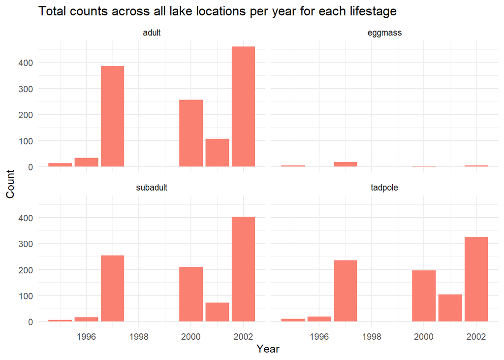

```r
# make a plot

frog_plot <- ggplot(summary_frogs, aes(x= year, y= count))+
  geom_col(fill = "salmon")+
  facet_wrap(~amphibian_life_stage)+
  labs(title = str_wrap("Total counts across all lake locations per year for each lifestage", 100),
       x= "Year",
       y= "Count")+
  theme_minimal()+
  theme(plot.title = element_text(size=13))

frog_plot
```

2. A column graph containing total counts (over all years of the study) of combined adult and subadult endangered mountain yellow-legged frogs (Rana muscosa) observed in the 5 lakes with the greatest total observed counts. In other words, this graph will have at least 5 columns (OK to have more if there are ties - thanks Michelle Shteyn), with Lake ID (these aren’t specified in the dataset for confidentiality) as the categorical label on one axis, and total yellow-legged frog counts (adult + subadult counts) in the dataset on the other axis. Make sure they’re in high-to-low or low-to-high order by total yellow-legged frog counts. You should exclude tadpoles for this graph. Note: Consider reformatting the lake ID from just a number to a label like “Lake 10025”), then use fct_reorder to convert it to an ordered factor.

```r
# get the top lakes

lakes <- filter_frogs %>%
  filter(amphibian_life_stage != "EggMass") %>%
 group_by(lake_id) %>%
  summarise(count = n()) %>%
  arrange(-count)
```